# Distribution simulation

Pratik A. Khare

2025-11-30

## Simulation Exercise

1. Below I will show the sample mean and compare it to the theoretical mean of the distribution.

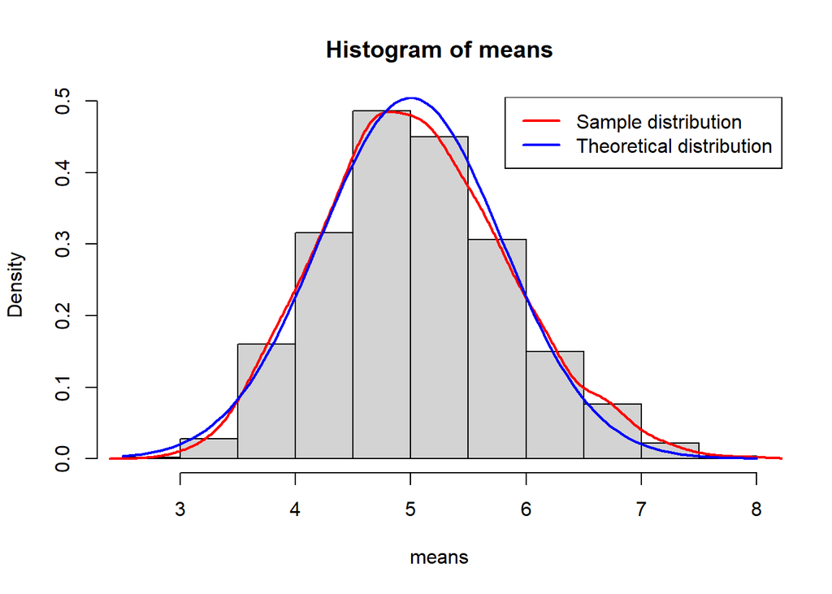

```r
means<-numeric(length(1000)) #Initialize the array "means"
for (i in 1:1000) { #loop through 1000 times for generating the rexp function
  expfunc <- rexp(40,0.2) #n=40, lambda=0.2
  means[i] <- mean(expfunc) #store the means of each of the iterations in the array "means"
}
sampmean <- mean(means) #The mean of all means in our sample mean
hist(means,freq=FALSE) #Plot histogram of the sample means. freq=FALSE displays the density instead of discrete counts
lines(density(means),col="red",lwd=2) #overlay the density curve atop it

curve(dnorm(x, mean=5, sd=5/sqrt(40)), add=TRUE, col="blue", lwd=2)
legend("topright", c("Sample distribution", "Theoretical distribution"),
       col = c("red", "blue"), lwd = 2)
```

Sample mean = 5.0447608 and theoretical mean = 1/0.2 = 5.

As seen in this plot, which compares the sample distribution and the theoretical distribution, the sample and theoretical means are very similar (close to 5)

2. Next, I will show how variable the sample is (via variance) and compare it to the theoretical variance of the distribution.

```r
sampvan<-numeric(length(1000)) #Initialize the array sampvan (sample variance)
for (j in 1:length(means)) { #Looping 1000 times
  sampvan[j] <- (means[j] - mean(means))^2 #storing the difference between each mean and the mean of means
}

sampvance <- sum(sampvan)/(length(sampvan)-1) #calculating the sample variance
theovance <- ((1/0.2)^2)/40 #theorteical variance calculation
```

Similarly, the sample variance is 0.6492152 and the theoretical variance is 0.625 which again, are very similar

3. Finally, I will show that the distribution is approximately normal.

To show this, let us compare how the distribution of a n=1000 exponential function looks like versus a simulation of the mean of 1000 n=40 exponential functions.

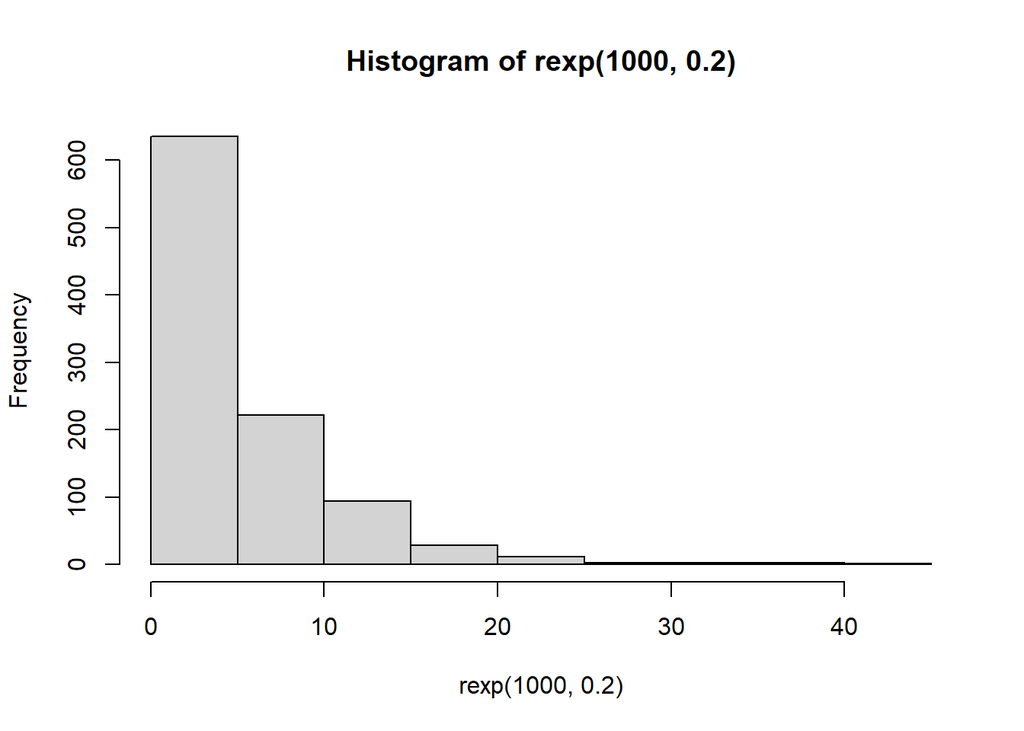

```r
hist(rexp(1000, 0.2)) #histogram of exponential function with n=1000 and lambda=0.2
```

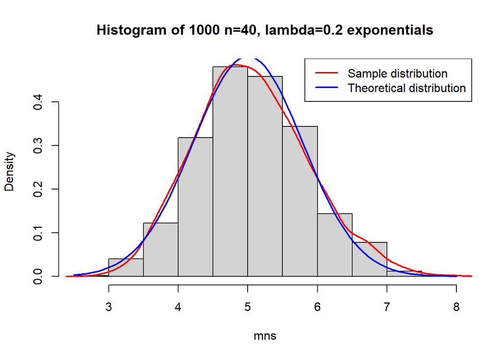

```r
mns = NULL
for (i in 1 : 1000) mns = c(mns, mean(rexp(40,0.2))) #array of mean of exponential with n=40 and lambda = 0.2
hist(mns, main="Histogram of 1000 n=40, lambda=0.2 exponentials",freq=FALSE) #histogram of mean of 1000 exponentials
lines(density(means),col="red",lwd=2) #overlay the density curve atop it #density curve for that histogram

curve(dnorm(x, mean=5, sd=5/sqrt(40)), add=TRUE, col="blue", lwd=2) #curve of a normal function with mean = 5 and sd = 5/sqrt(40)
legend("topright", c("Sample distribution", "Theoretical distribution"),
       col = c("red", "blue"), lwd = 2)
```

This clearly shows that the latter is a normal distribution centered about 5. Moreover upon overlaying this with a normal distribution centered about 5 and having a std dev of 5/sqrt(40) proves that the distribution of 1000 n=40, lambda=0.2 exponentials is approximately normal.